# Survey Progress Report

University of Liberia School of Public Health Research Team

2022-05-22 20:09:33

## Survey progress per team

The following bar plots show number of records/forms submitted by each team per enumeration area. Each bar plot indicates the day in which each record/form was started or initiated. These bar plots can be used to assess the number of enumeration areas teams and/or enuemrators are able to visit and start/initiate data collection within.

### Team 1

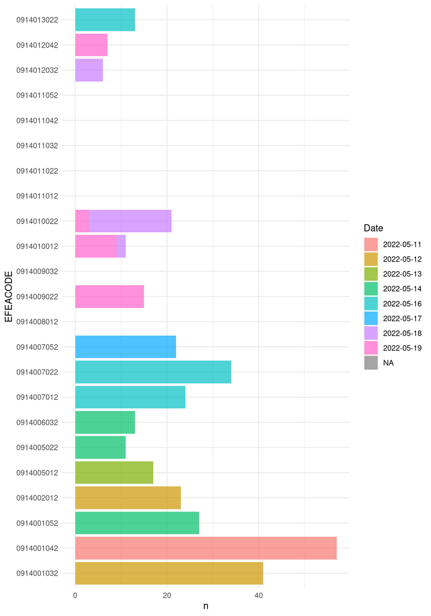

**Team 1 overall median survey time:** 11.26 minutes  
**Team 1 daily median survey time:** NA minutes

### Team 2

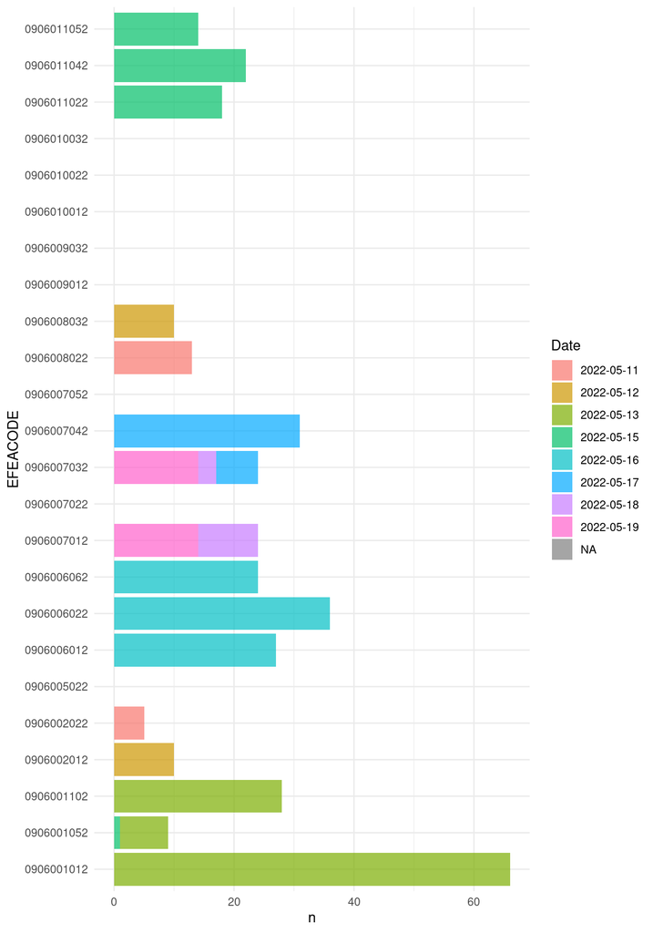

**Team 2 overall median survey time:** 1691.43 minutes  
**Team 2 daily median survey time:** NA minutes

### Team 3

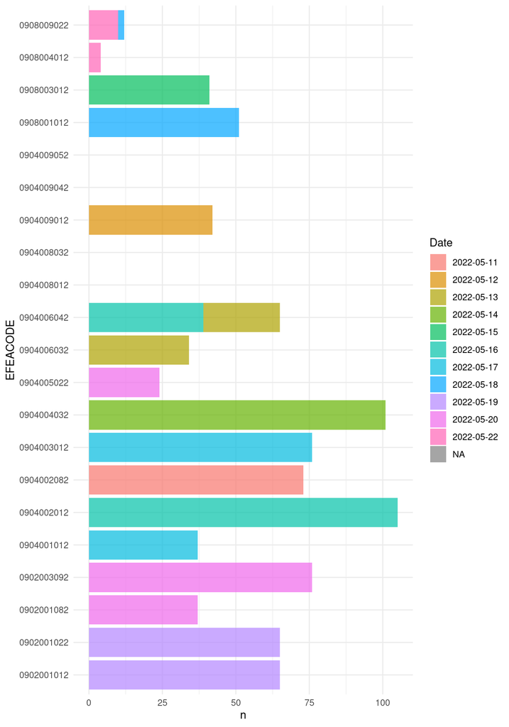

**Team 3 overall median survey time:** 204.27 minutes  
**Team 3 daily median survey time:** 5.93 minutes

### Team 4

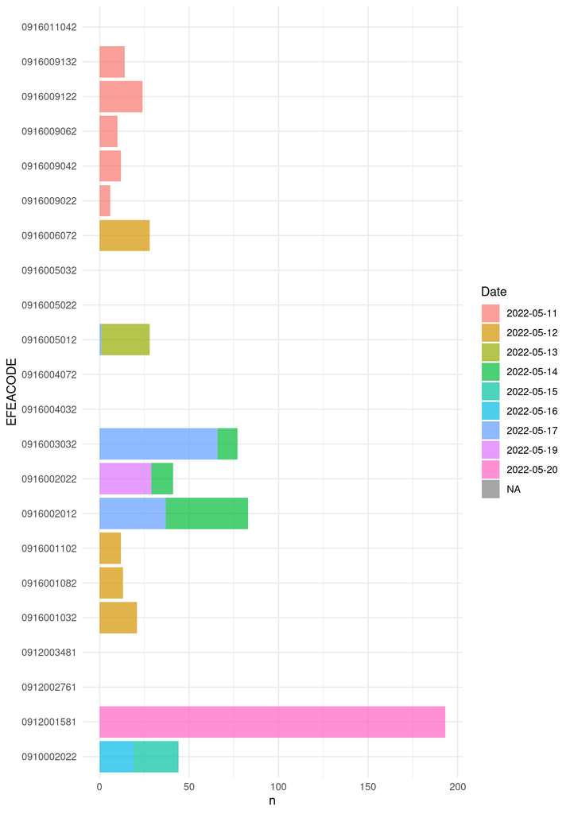

**Team 4 overall median survey time:** 688.3 minutes  
**Team 4 daily median survey time:** NA minutes

### Team 5

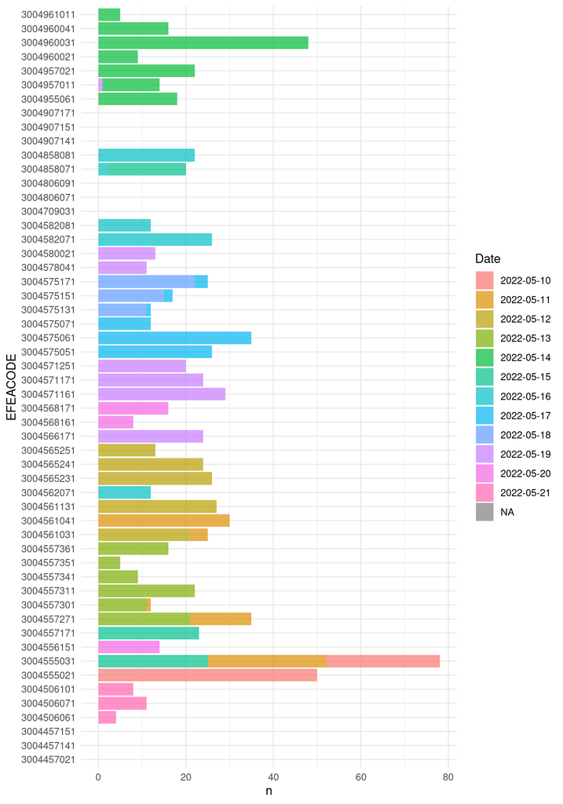

**Team 5 overall median survey time:** 6.01 minutes  
**Team 5 daily median survey time:** NA minutes

### Team 6

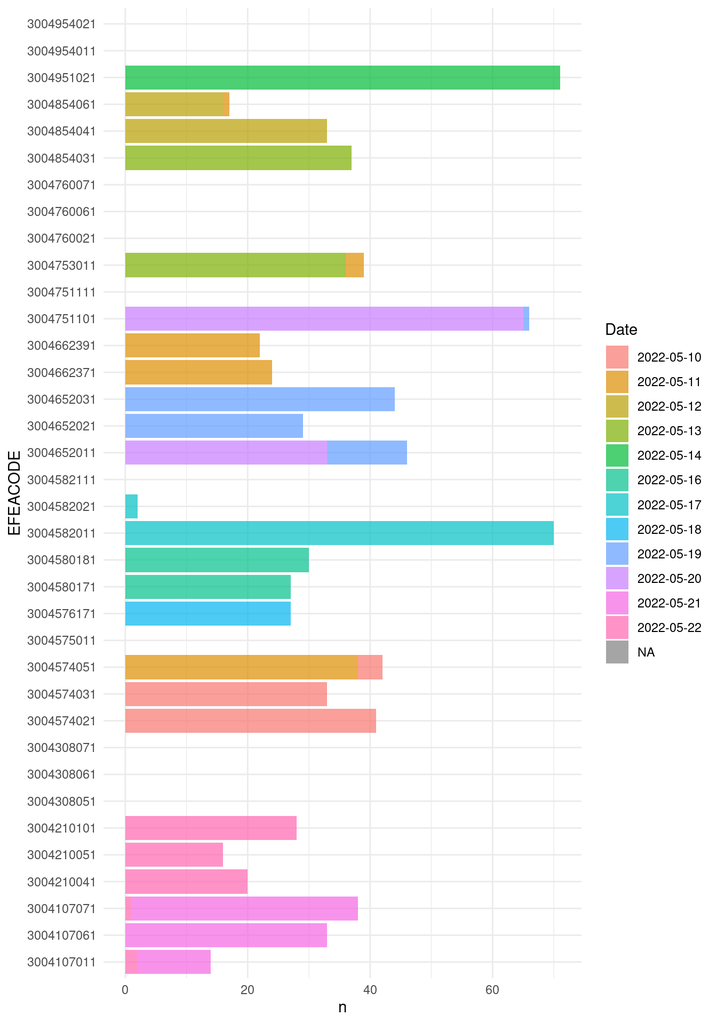

**Team 6 overall median survey time:** 4.27 minutes  
**Team 6 daily median survey time:** 4.97 minutes